# Lecture 10 Estimation of Difference in Differences

Nick Huntington-Klein

2021-01-14

## Difference-in-Differences

- The basic idea is to take fixed effects *and then compare the within variation across groups*
- We have a treated group that we observe *both before and after they’re treated*
- And we have an untreated group
- The treated and control groups probably aren’t identical - there are back doors! So… we *control for group* like with fixed effects

## Today

- Last time we compared means by hand
- How can we get standard errors? How can we add controls? What if there are more than two groups?
- We’ll be going over how to implement DID in regression *and other methods*
- Remember, regression is just a tool

## Two-Way Fixed Effects

- We want an estimate that can take *within variation* for groups
- also adjusting for time effects
- and then compare that within variation across treated vs. control groups
- Sounds like a job for fixed effects!

## Two-way Fixed Effects

- For standard DID where treatment goes into effect at a particular time, we can estimate DID with

$$Y = \beta_i + \beta_t + \beta_1Treated + \varepsilon$$

- Where $\beta_i$ is group fixed effects, $\beta_t$ is time-period fixed effects, and $Treated$ is a binary indicator equal to 1 if you are currently being treated (in the treated group and after treatment)
- $Treated = TreatedGroup\times After$
- Typically run with standard errors clusteed at the group level (why?)

## Two-way Fixed Effects

- Why this works is a bit easier to see if we limit it to a “2x2” DID (two groups, two time periods)

$$Y = \beta_0 + \beta_1TreatedGroup + \beta_2After + \beta_3TreatedGroup\times After + \varepsilon$$

- $\beta_1$ is prior-period group diff, $\beta_2$ is shared time effect
- $\beta_3$ is *how much bigger the $TreatedGroup$ effect gets after treatment vs. before, i.e. how much the gap grows
- Difference-in-differences!

## Two-way Fixed Effects

```r
tb <- tibble(groups = sort(rep(1:10,600)), time = rep(sort(rep(1:6,100)),10)) %>%
  # Groups 6-10 are treated, time periods 4-6 are treated
  mutate(Treated = I(groups>5)*I(time>3)) %>%
  # True effect 5
  mutate(Y = groups + time + Treated*5 + rnorm(6000))

m <- feols(Y ~ Treated | groups + time, data = tb)

msummary(m, stars = TRUE, gof_omit = 'AIC|BIC|Lik|F|Pseudo|Adj')
```

|  | Model 1 |
| --- | --- |
| Treated | 4.985*** |
|  | (0.038) |
| Num.Obs. | 6000 |
| R2 | 0.962 |
| R2 Within | 0.603 |
| Std. errors | Clustered (groups) |

* p < 0.1, ** p < 0.05, *** p < 0.01

## Example

- As a quick example We’ll use `data(injury)` from `library(wooldridge)`
- This is from Meyer, Viscusi, and Durbin (1995) - In Kentucky in 1980, worker’s compensation law changed to increase benefits, but only for high-earning individuals
- What effect did this have on how long you stay out of work?
- The treated group is individuals who were already high-earning, and the control group is those who weren’t

## Example

```r
data(injury, package = 'wooldridge')
injury <- injury %>%
  filter(ky == 1)  %>% # Kentucky only
  mutate(Treated = afchnge*highearn)
m <- feols(ldurat ~ Treated | highearn + afchnge, data = injury)
msummary(m, stars = TRUE, gof_omit = 'AIC|BIC|Lik|Adj|Pseudo')
```

|  | Model 1 |
| --- | --- |
| Treated | 0.191*** |
|  | (0.000) |
| Num.Obs. | 5626 |
| R2 | 0.021 |
| R2 Within | 0.001 |
| FE: afchnge | X |
| FE: highearn | X |
| Std. errors | Clustered (highearn) |

* p < 0.1, ** p < 0.05, *** p < 0.01

## Interpretation

- The coefficient on $Treated$ is how much more the treated group(s) changed than the untreated group(s) (DID)
- Not shown in the table, but the coefficient on the group FEs is how different the groups are before treatment
- And the coefficient on the time FEs is the shared time change

## Picking Controls

- For this to work we have to *pick the control group* to compare to
- How can we do this?
- We just need a control group for which parallel trends holds - if there had been no treatment, both treated and untreated would have had the same time effect
- We can’t check this directly (since it’s counterfactual), only make it plausible
- More-similar groups are likely more plausible, and nothing should be changing for the control group at the same time as treatment

## Checking Parallel Trends

- There are two main ways we can use *prior* trends to at least test the plausibility of parallel trends, if not test parallel trends directly itself
- First, we can check for differences in *prior trends*
- Second, we can do a *placebo test*

## Prior Trends

- If the two groups were already trending towards each other, or away from each other, before treatment, it’s kind of hard to believe that parallel trends holds
- They *probably* would have continued trending together/apart, breaking parallel trends. We’d mix up the continuation of the trend with the effect of treatment
- We can test this by looking for differences in trends with an interaction term.
- Also, *look at the data*! We did that last time.
- Sometimes people “fix” a difference in prior trends by controlling for prior trends by group, but tread lightly as this can introduce its own biases!

## Prior Trends

- This is done with a polynomial trend here (since it’s trickier) but could easily be linear
- Using EITC again but with a regression rather than visual inspection
- There are only three pre-treatment periods so linear would probably be better but this is an example

```r
df <- read_csv('http://nickchk.com/eitc.csv') %>%
  mutate(treated = children > 0) %>%
  filter(year <= 1994) # use only pre-treatment data (fudging a year here so I can do polynomial)
m <- lm(work ~ year*treated + I(year^2)*treated, data = df)
```

## Prior Trends

|  | Model 1 |
| --- | --- |
| (Intercept) | 30895.713 |
|  | (30603.436) |
| year | -31.014 |
|  | (30.719) |
| treatedTRUE | 16232.668 |
|  | (40517.563) |
| I(year^2) | 0.008 |
|  | (0.008) |
| year × treatedTRUE | -16.293 |
|  | (40.670) |
| treatedTRUE × I(year^2) | 0.004 |
|  | (0.010) |
| Num.Obs. | 9656 |

* p < 0.1, ** p < 0.05, *** p < 0.01

## Prior Trends

- Test if the interaction terms are jointly significant

```r
library(car)
linearHypothesis(m, c('year:treatedTRUE','treatedTRUE:I(year^2)'))
```

```
## Linear hypothesis test
##
## Hypothesis:
## year:treatedTRUE = 0
## treatedTRUE:I(year^2) = 0
##
## Model 1: restricted model
## Model 2: work ~ year * treated + I(year^2) * treated
##
##   Res.Df    RSS Df Sum of Sq      F Pr(>F)
## 1   9652 2373.3
## 2   9650 2373.3  2  0.045462 0.0924 0.9117
```

- Fail to reject - no evidence of differences in prior trends. That doesn’t *prove* parallel trends but failing this test would make prior trends less *plausible*

## Placebo Tests

- Many causal inference designs can be tested using *placebo tests*
- Placebo tests pretend there’s a treatment where there isn’t one, and looks for an effect
- If it finds one, that indicates there’s something wrong with the design, finding an effect when we know for a fact there isn’t one
- In the case of DID, we could (rare) drop the treated groups and pretend some untreated groups are treated, look for effects, or (common) drop the post-treatment data, pretend treatment happens at a different time, and check for an effect

## Placebo Tests

```r
# Remember we already dropped post-treatment. Years left: 1991, 1992, 1993, 1994. We need both pre- and post- data,
# So we can pretend treatment happened in 1992 or 1993

m1 <- feols(work ~ Treatment | treated + year, data = df %>%
              mutate(Treatment = treated & year >= 1992))
m2 <- feols(work ~ Treatment | treated + year, data = df %>%
              mutate(Treatment = treated & year >= 1993))

msummary(list(m1,m2), stars = TRUE, gof_omit = 'Lik|AIC|BIC|F|Pseudo|Adj')
```

|  | Model 1 | Model 2 |
| --- | --- | --- |
| TreatmentTRUE | -0.008*** | -0.003*** |
|  | (0.000) | (0.000) |
| Num.Obs. | 9656 | 9656 |
| R2 | 0.017 | 0.017 |
| R2 Within | 0.000 | 0.000 |
| Std. errors | Clustered (treated) | Clustered (treated) |

* p < 0.1, ** p < 0.05, *** p < 0.01

## Prior Trends and Placebo

- Uh oh! Those are significant effects! (keeping in mind I snuck 1994 in to make the code work better which is actually post-treatment)
- For both placebo tests and, especially, prior trends, we’re a little less concerned with significance than *meaningful size* of the violations
- After all, with enough sample size *anything* is significant
- And those treatment effects are fairly tiny

## Dynamic DID

- We’ve limited ourselves to “before” and “after” but this isn’t all we have!
- But that averages out the treatment across the entire “after” period. What if an effect takes time to get going? Or fades out?
- We can also estimate a *dynamic effect* where we allow the effect to be different at different lengths since the treatment
- This also lets us do a sort of placebo test, since we can also get effects *before* treatment, which should be zero

## Dynamic DID

- Simply interact $TreatedGroup$ with binary indicators for time period, making sure that the last period before treatment is expected to show up is the reference

$$Y = \beta_0 + \beta_tTreatedGroup + \varepsilon$$

- Then, usually, plot it. **fixest** makes this easy with its `i()` interaction function

## Dynamic DID

```r
df <- read_csv('eitc.csv') %>%
  mutate(treated = 1*(children > 0)) %>%
  mutate(year = factor(year))
m <- feols(work ~ i(treated, year, drop = '1993') | treated + year, data = df)
```

## Dynamic DID

|  | Model 1 |
| --- | --- |
| treated × year × × 1991 | 0.011*** |
|  | (0.000) |
| treated × year × × 1992 | 0.001*** |
|  | (0.000) |
| treated × year × × 1994 | 0.007*** |
|  | (0.000) |
| treated × year × × 1995 | 0.067*** |
|  | (0.000) |
| treated × year × × 1996 | 0.084*** |
|  | (0.000) |
| Num.Obs. | 13746 |
| R2 | 0.013 |
| R2 Within | 0.001 |
| Std. errors | Clustered (treated) |

* p < 0.1, ** p < 0.05, *** p < 0.01

## Dynamic DID

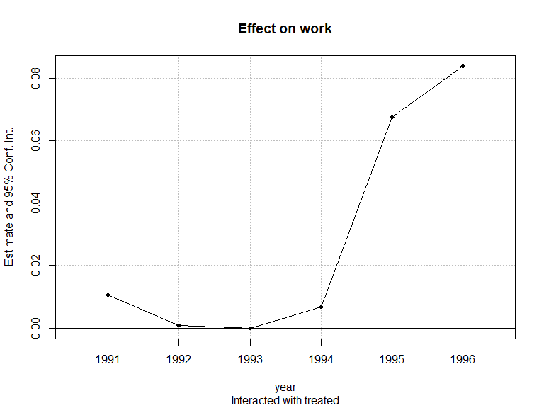

```r
coefplot(m, ref = c('1993' = 3), pt.join = TRUE)
```

## Dynamic DID

- We see no effect before treatment, which is good
- No *immediate* effect in 1994, but then a consistent effect afterwards

## Problems with Two-Way Fixed Effects

- One common variant of difference-in-difference is the *rollout design*, in which there are multiple treated groups, each being treated at a different time
- For example, wanting to know the effect of gay marriage on $Y$, and noting that it became legal in different states at different times before becoming legal across the country
- Rollout designs are possibly the most common form of DID you see

## Problems with Two-Way Fixed Effects

- And yet!
- As discovered *recently* (and popularized by Goodman-Bacon 2018), two-way fixed effects does *not* work to estimate DID when you have a rollout design
- (uh-oh… we’ve been doing this for decades!)
- Why not?

## Problems with Two-Way Fixed Effects

- Think about what fixed effects does - it leaves you only with within variation
- Two types of individuals without *any* within variation between periods A and B: the never-treated and the already-treated
- So the already-treated can end up getting used as controls in a rollout
- This becomes a big problem especially if the effect grows/shrinks over time. We’ll mistake changes in treatment effect for effects of treatment, and in the wrong direction!

## Callaway and Sant’Anna

- There are a few new estimators that deal with rollout designs properly. One is Callaway and Sant’Anna (see the **did** package)
- They take each period of treatment and consider the group treated *on that particular period*
- They explicitly only use untreated groups as controls
- And they also use *matching* to improve the selection of control groups for each period’s treated group
- We won’t go super deep into this method, but it is one way to approach the problem

## Concept Checks / Practice

- Why does two-way fixed effects give the DID estimate (when treatment only occurs at one time period)?
- Why might we be particularly interested in seeing how the DID estimate changes relative to the treatment period?
- Why might we want to cluster our standard errors at the group level in DID?